# La régionalisation du Monde

Cours L3 Géographie 2025

Claude Grasland

2025-03-24

# Introduction : Intégration régionale et régionalisme

## Deux ouvrages de référence

[figure not shown]

- Une synthèse des réflexions des géographes français en 2014 sur les rapports entre **régionalisation** et **mondialisation** autour des concets d’**intégration régionale** et de **régionalisme**. Contenu du livre accessible [en ligne](https://www.cairn.info/la-regionalisation-du-monde--9782811111403.htm)

## Deux ouvrages de référence

[figure not shown]

- Une mise à jour de l’ouvrage précédent effectuée en 2018 sous la forme d’un **dictionnaire des concepts** comprenant plusieurs **études de cas**.

## Régionalisation : définition

- La régionalisation désigne une **augmentation des échanges entre des unités territoriales situées dans la même partie du monde**. Il peut s’agir de pays, de régions ou d’autres entités infra étatiques.
- La régionalisation aboutit à ce que **les échanges internes à ce paquet d’unités territoriales soient plus élevés ou plus intenses qu’avec le reste du monde**.
- Dans certains cas, les échanges internes sont effectivement plus élevés que les échanges externes. Dans d’autres cas, leur part est minoritaire mais leur augmentation est plus rapide. Dans le premier cas, la régionalisation est un **fait établi**. Dans l’autre, elle est un **processus en cours**.

Source : Y. Richard, 2014, “Régionalisation, régionalisme et intégration régionale : concepts flous et nécessaire clarification”, in [Richard Y. & Gana A., 2014](https://www.cairn.info/la-regionalisation-du-monde--9782811111403-page-21.htm)

## Régionalisation : exemple théorique

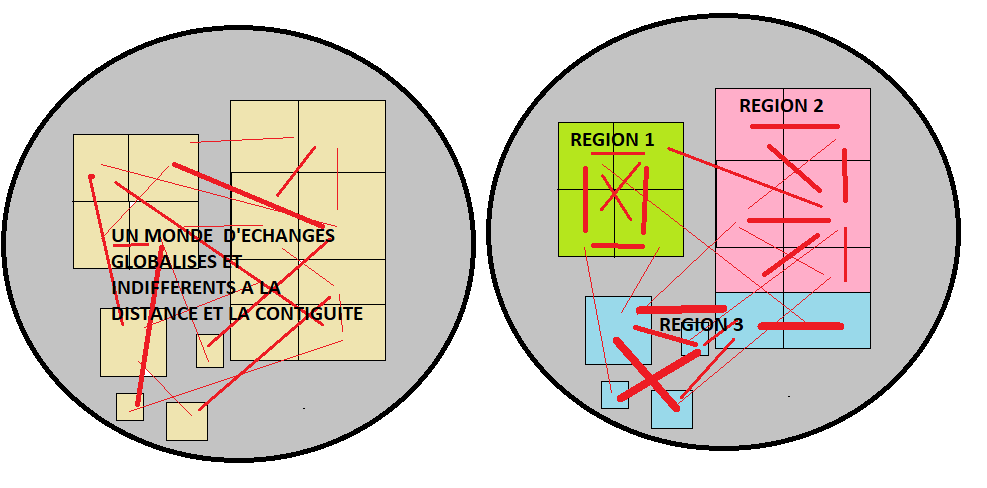

- **à gauche**, un monde **globalisé** où les relations entre pays sont indifférentes aux coûts de transports et aux frontières. ..
- **à droite**, un monde **régionalisé** où les échanges se concentrent entre les pays voisins (**régions 1 et 2**) ou des pays proches reliés par des routes marines (**région 3**)

## Régionalisation : un fait établi ?

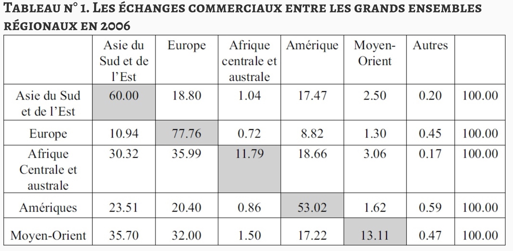

Source : G. van Hamme, 2014, “Régionalisme, intégration régionale et mondialisation : quelques éclairages sur un triangle complexe”, in [Richard Y. & Gana A., 2014](https://www.cairn.info/la-regionalisation-du-monde--9782811111403-page-45.htm)

## Régionalisation et mondialisation

- Dans le contexte idéologique libéral des années 1990, l’**intégration économique régionale a été perçue par de nombreux auteurs comme une menace potentielle au développement économique** (Krugman, 1991 ; Frankel et al., 1995). Cette crainte s’appuie, d’une part, sur l’idée que la **libre circulation généralisée des biens et services** est le meilleur chemin vers la prospérité économique et, d’autre part, que le régionalisme pourrait être un frein à l’ouverture économique.
- Mais, dès la fin des années 1990, ces craintes s’estompent car **les aires de libre-échange régional n’ont pas mené de politique protectionniste, bien au contraire** (*cf. cas de l’UE*)
- D’une part, en favorisant les processus d’agglomération économique sur des marchés plus larges, **la régionalisation permettrait en particulier aux économies les plus faibles de mieux faire face à une ouverture économique plus large**. D’autre part, d’un point de vue plus politique, **le libre-échange régional se heurte à de moindres résistances que l’ouverture commerciale tous azimuts**.

Source : G. van Hamme, 2014, “Régionalisme, intégration régionale et mondialisation : quelques éclairages sur un triangle complexe”, in [Richard Y. & Gana A., 2014](https://www.cairn.info/la-regionalisation-du-monde--9782811111403-page-45.htm)

## Régionalisation et mondialisation

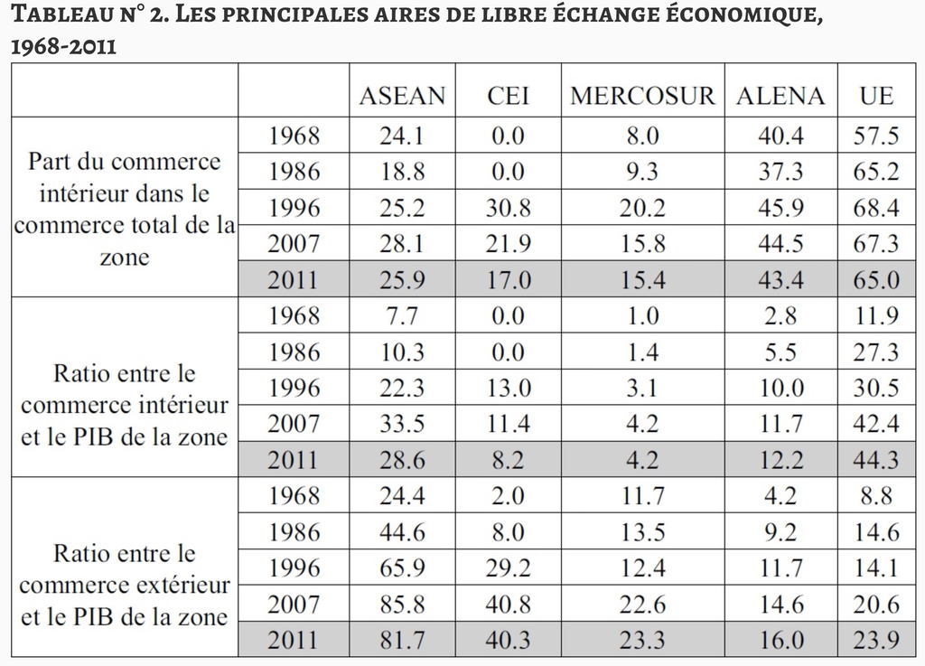

Source : G. van Hamme, 2014, “Régionalisme, intégration régionale et mondialisation : quelques éclairages sur un triangle complexe”, in [Richard Y. & Gana A., 2014](https://www.cairn.info/la-regionalisation-du-monde--9782811111403-page-45.htm)

## Régionalisation : un processus multisectoriel

- La régionalisation est un processus multisectoriel qui **ne se limite pas au commerce** (échanges de marchandises, de services et d’investissements). Tous les flux ou autres modes de relations peuvent se régionaliser : **flux touristiques, migrations ou mobilités internationales, aide au développement, communications téléphoniques et électroniques…**
- C’est **une dynamique qui dessine et redessine en permanence des ensembles géographiques aux limites mouvantes**. Ces limites peuvent se confondre avec le tracé des frontières de certains États ou bien passer au milieu de leur territoire.
- Parler de régionalisation revient à mettre l’accent sur le **processus en cours** ou sur le résultat indépendamment de ses causes.

Source : Y. Richard, 2014, “Régionalisation, régionalisme et intégration régionale : concepts flous et nécessaire clarification”, in [Richard Y. & Gana A., 2014](https://www.cairn.info/la-regionalisation-du-monde--9782811111403-page-21.htm)

## Régionalisme : définition

- Le régionalisme implique l’idée d’une **action consciente et planifiée**, d’une **stratégie**. Il a pour origine un ensemble de décisions prises par des acteurs situés dans la même partie du monde à un moment donné.
- On peut parler par exemple de régionalisme lorsque plusieurs États voisins tentent d’**abaisser les barrières douanières** qui les séparent.
- Les acteurs du régionalisme sont en général des **États** qui souhaitent donner un caractère organisé ou mieux régulé à leurs relations de voisinage. Chez la plupart des auteurs, le régionalisme implique donc l’idée d’une **coopération politique** voire d’une **coordination à l’échelon gouvernemental**.

Source : Y. Richard, 2014, “Régionalisation, régionalisme et intégration régionale : concepts flous et nécessaire clarification”, in [Richard Y. & Gana A., 2014](https://www.cairn.info/la-regionalisation-du-monde--9782811111403-page-21.htm)

## Régionalisme : point de vue économique

- L’**économie** accorde beaucoup d’attention au régionalisme depuis les années 1950. Elle le définit comme la **signature d’un accord régional ou de plusieurs accords commerciaux préférentiels bilatéraux signés par des États voisins**, afin de faciliter leurs échanges. Ces accords concernent principalement le commerce et/ou les investissements.
- Un premier type est caractérisé par l’**association de pays ayant des niveaux de développement égaux ou presque égaux** qui signent des accords commerciaux de plus en plus nombreux et de plus en plus exigeants.
- Un deuxième type implique des **pays aux niveaux de développement inégaux** qui mettent en place une division internationale hiérarchisée du travail. On parle alors de **régionalisme Nord-Sud**.

Source : Y. Richard, 2014, “Régionalisation, régionalisme et intégration régionale : concepts flous et nécessaire clarification”, in [Richard Y. & Gana A., 2014](https://www.cairn.info/la-regionalisation-du-monde--9782811111403-page-21.htm)

## Régionalisme : situation vers 2010

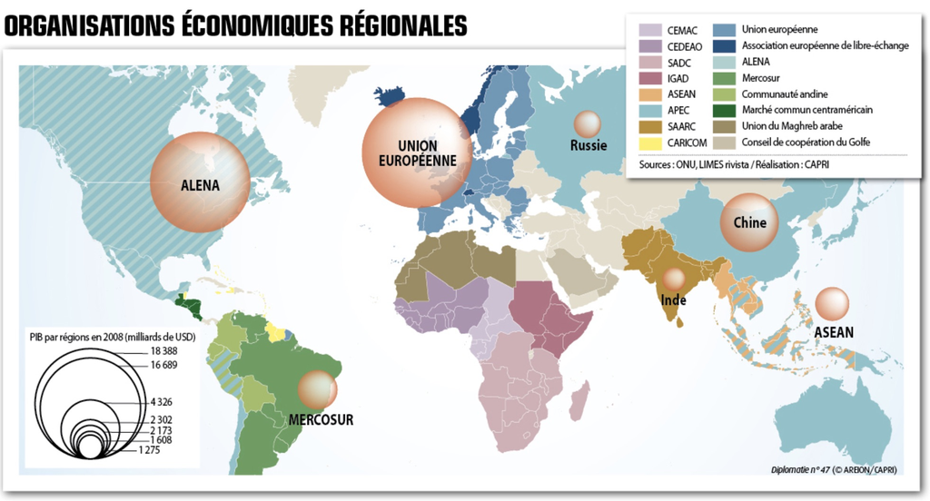

- Une vision simple et rassurante de blocs économiques bien séparés où les pays occidents pèsent le plus sur le plan économique. Source : Diplomatie, n°47

## Régionalisme : situation vers 2020

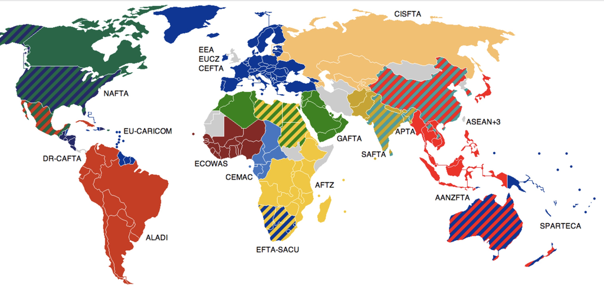

- Une vision complexe de zones de libre échanges multiples qui se chevauchent et s’intersectent sans logique claire. Source : Wikipedia, english, consulté le 8 mars 2022

## Le conflit russo-ukrainien de 2013-2014

- Le conflit russo-ukrainien de 2013-2014 qui aboutit à l’annexion de la Crimée et la première guerre du Donbass trouve son point de départ dans un **arbitage géopolitique entre deux visions de l’intégration régionale du pays dans le Monde**.
- **La Communauté des États indépendants (CEI)** signe un accord de libre-échange signé le 18 octobre 2011 entre la **Russie, l’Ukraine, la Biélorussie, la Moldavie, l’Arménie, le Kirghizstan et le Kazakhstan** afin de renforcer les échanges entre les pays. Mais sa ratification prend du temps et n’est pas achevée en 2013 et sera abandonnée.
- **L’Union Européenne** de son côté propose à l’Ukraine un **accord d’association** qui est négocié de 2007 à 2012 pour entrer en vigueur en novembre 2013. Mais le président ukrainien **Vladimir Ianoukovitch** refuse de le ratifier ce qui provoque les événements de Maïdan, suivi de sa destitution et sa fuite en Russie. L’Ukraine rejoint l’accord avec l’UE en 2017.

## Le conflit russo-ukrainien de 2013-2014

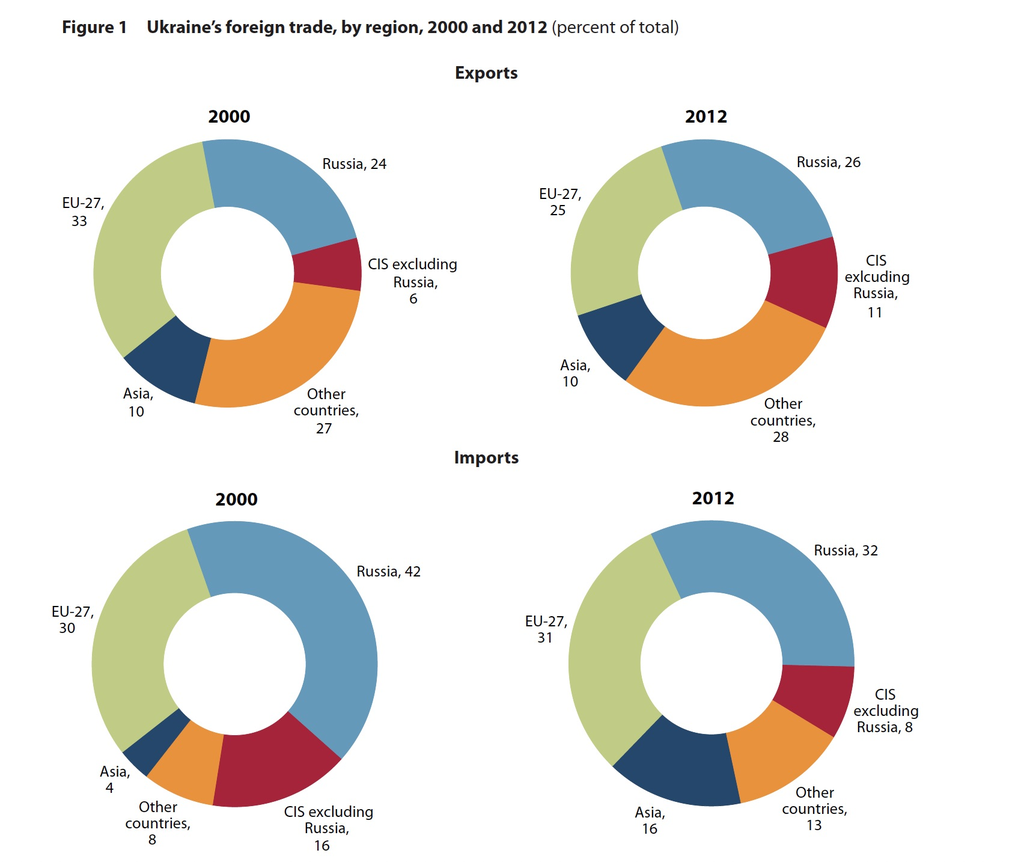

- Quelques semaines avant le conflit, un document d’analyse économique s’interroge sur le choix de l’Ukraine qui commerce à part approximativement égale avec les deux blocs.

Source : Anders Aslund, Sept. 2013, “Ukraine’s Choice: European Association Agreement or Eurasian Union?”, Policy Brief n°22 of the Peterson Institute for International Economics. Lien

## Du régionalisme à l’intégration régionale

- **Le politiste Joseph Nye (1968)** discute le concept d’**intégrations régionales** et propose d’étudier en parallèle dans une partie du monde donnée l’intégration **économique**, l’intégration **sociale** et l’intégration **politique**, chacun de ces types d’intégration pouvant à son tour être divisé en sous-types (Nye, 1968) et entrer en interaction avec les autres.
- **L’économiste H. Regnault (1986)** pense que le régionalisme peut correspondre “à un besoin de relations étroites en vue de former bloc au sein de l’économie mondiale. Cela implique l’engagement dans un processus d’**intégration en profondeur**. Outre la proximité géographique, l’exclusivité de la relation suppose « **un vouloir vivre ensemble** » ou, au minimum, la **conscience d’un « devoir vivre ensemble** », ce qui en fait un projet géopolitique global, non réductible à la seule logique économique .

## L’intégration régionale : définition

- L’**intégration régionale désigne un processus de création, d’accroissement et d’approfondissement des interactions entre des unités territoriales initialement distinctes et contiguës**.
- Le processus aboutit à la formation d’un **ensemble régional autonome** à l’intérieur duquel les interactions entre les territoires constitutifs sont plus fortes qu’avec les territoires externes. Les ensembles régionaux ainsi construits peuvent être de toutes tailles.
- Ils peuvent être constitués par les territoires additionnés de plusieurs **pays contigus**, ou former des **ensembles transnationaux** déployés sur le territoire de plusieurs États sans nécessairement inclure ceux-ci en entier, pourvu qu’il n’y ait pas de rupture de la **continuité spatiale**

Source : Y. Richard, 2014, “Régionalisation, régionalisme et intégration régionale : concepts flous et nécessaire clarification”, in [Richard Y. & Gana A., 2014](https://www.cairn.info/la-regionalisation-du-monde--9782811111403-page-21.htm)

## En résumé :

1. la **régionalisation** est la mise en évidence d’espace voisins ou proches ayant plus de liens entre eux qu’avec le reste du Monde et/ou qui renforcent ces liens. Elle relève donc d’une **analyse économique et géographique** de l’organisation du Monde par les **flux**.
2. Le **régionalisme** est un processus **politique et juridique** de création de territoires de circulation préférentielle qui favorisent les échanges entre des lieux proches en réduisant les distances et abolissant les frontières.
3. L’**intégration régionale*** est le résultat de la combinaison dialectique des deux processus précédents. L’existence de flux ou de liens entre pays proches (*régionalisation*) peut conduire ceux-ci à mettre en place une structure politique (*régionalisme*) qui va contribuer en retour à renforcer les flux.
4. Si la **dimension économique** est la plus souvent mise en avant, les processus d’intégration régionale sont **multifactoriels** et combinent aussi bien des dimensions objectives (e.g. complémentarités) que des dimensions subjectives (e.g. sentiments d’identités)

# LE DECOUPAGE DU MONDE EN CONTINENTS

## A quelle “région du Monde” appartenez-vous ?

#### Etudiants de géographie (2025)

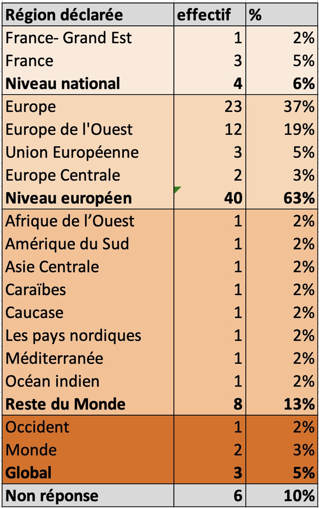

Source : Enquête SMA 2025, U. Paris Cité

#### Etudiants France métropolitaine (2021)

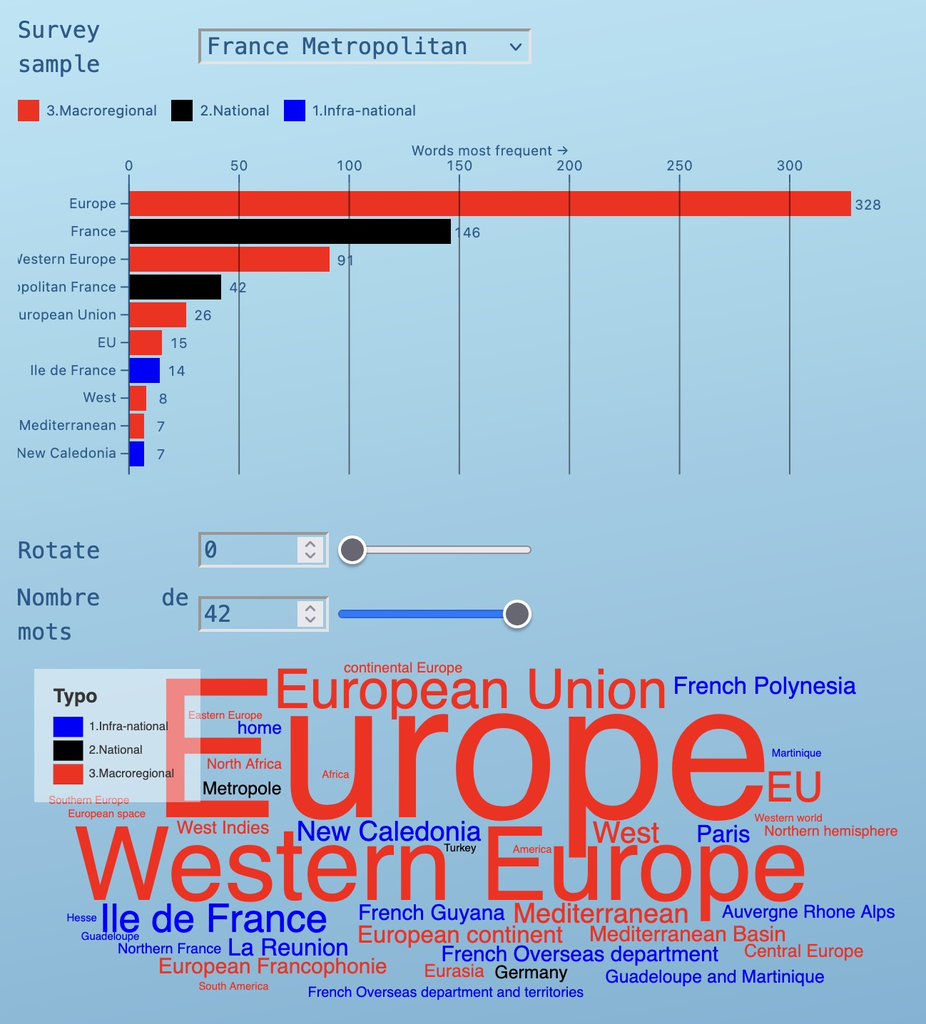

[Source : Enquête IMAGEUN, 2020-2021](https://elinamx.github.io/atlas-imageun/docs/france.html)

## Un découpage ternaire inventé au Moyen-Âge par les Européens …

[figure not shown]

[figure not shown]

Source : **Grataloup, Christian, 2009,** *L’invention des continents: comment l’Europe a découpé le monde*. Larousse, Paris.

## … à partir de textes religieux …

L’humanité, selon la Genèse, descend des trois fils de Noé : Sem, Japhet et Cham. Le texte biblique ne nous indique pas les directions dans lesquelles ils partent, mais des listes de lieux. On pouvait en déduire que Sem était parti vers l’Est, Japhet vers le Nord- Ouest et Cham vers le Sud-Ouest. On en a déduit longtemps que l’humanité était divisée en trois « races », auxquelles devaient correspondre trois territoires : **L’Asie pour les descendants de Sem, l’Afrique pour ceux de Cham et l’Europe pour ceux de Japhet**.

[figure not shown]

## … utilisés plus tard pour justifier la traite négrière.

D’après la Bible, après le Déluge, Noé réinvente l’agriculture et replante, entre autres, la vigne. Il s’enivre et, dans le lourd sommeil qui suit son ivresse, il se dénude de façon impudique. Son benjamin, Cham, le voit, s’en amuse et avertit ses frères aînés. Ces derniers, refusant de voir ainsi leur père, s’approchent à reculons pour le couvrir de son manteau. A son réveil, Noé le blâme et maudit le fils de Cham, Canaan ; **il est condamné ainsi que sa descendance à être les « serviteurs des serviteurs » des descendants de Sem et Japhet**.

[figure not shown]

Source : Grataloup C.

## Un découpage binaire lié aux grandes découvertes …

#### Planisphère de Waldseemüller (1503)

[figure not shown]

#### Carte de Mallet (1683)

[figure not shown]

## … qui oppose Ancien et Nouveau Monde ….

#### Carte de Malte-Brun (1836)

[figure not shown]

## … et fait passer le nombre de continents à quatre, cinq, six …

#### Manuel de Géographie de Demangeon (1955)

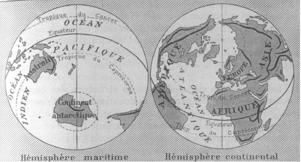

## … ou sept, non sans incertitudes !

#### Page Wikipedia consacrée aux continents

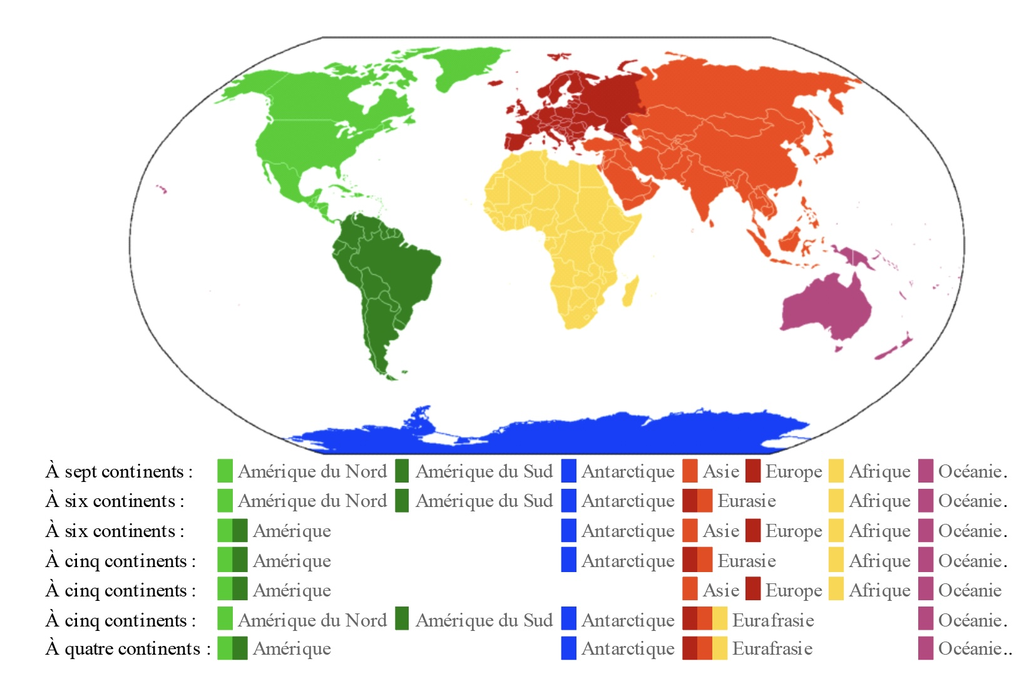

## Mais qu’est-ce au juste qu’un continent ?

#### Dictionnaire Le Robert

1. Grande étendue de terre limitée par un ou plusieurs océans.
2. Partie du monde. Les six continents : l’Europe, l’Asie, l’Afrique, l’Amérique, l’Océanie et l’Antarctique.
3. La terre par rapport à une île.

#### L’exemple du jeu Civilization

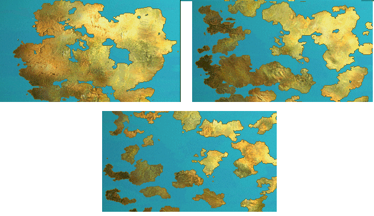

Options de jeu : “*Pangée*”, “*Continents*” \ ou “*Archipel*”

## Une définition formelle ?

- **6.341** Représentons nous une surface blanche couverte de taches noires et irrégulières. Et nous dirons : Quelle que soit l’image qui en résulte, je puis toujours en donner la description approximative qu’il me plaira, en couvrant la surface d’un filet fin adéquat à mailles carrées et dire de chaque carré qu’il est blanc ou noir. De cette manière, j’aurais donné **une forme unifiée à la description de la surface.**

**Cette forme est arbitraire**, car j’aurais pu tout aussi bien me servir d’un filet à mailles triangulaires ou hexagonales et obtenir un résultat non moins satisfaisant.

**A ces différents filets correspondent différents systèmes de la description de l’univers**.

## Une définition formelle ?

#### 21 continents ?

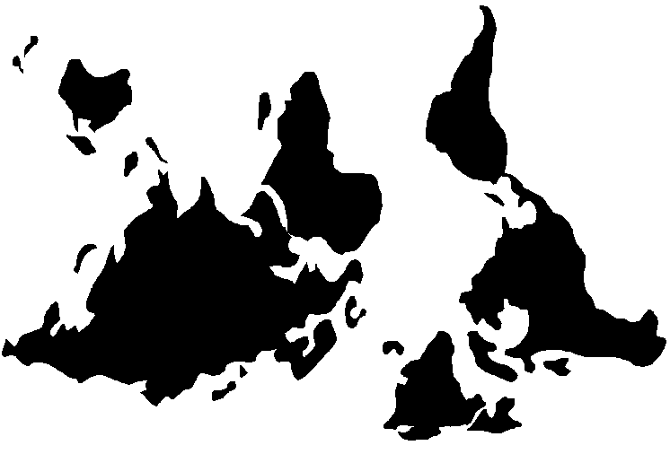

## Une définition formelle ?

#### 14 continents ?

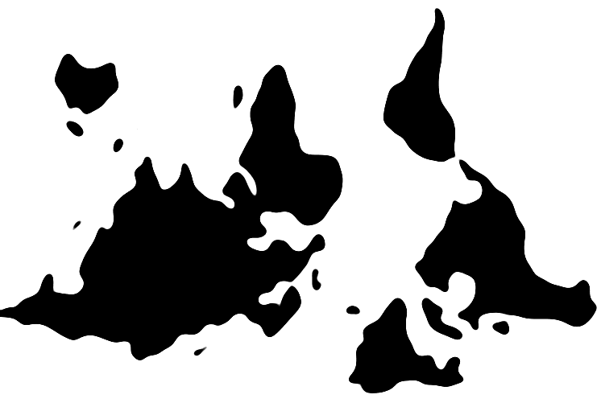

## Une définition formelle ?

#### 6 continents

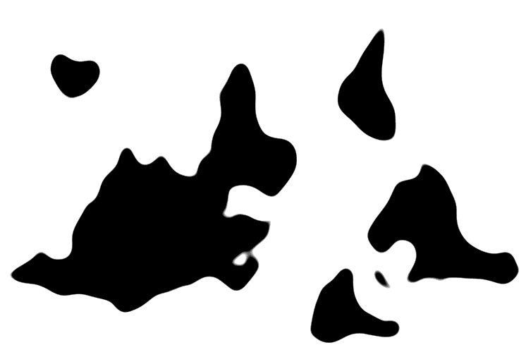

## Une définition formelle ?

#### 2 continents ?

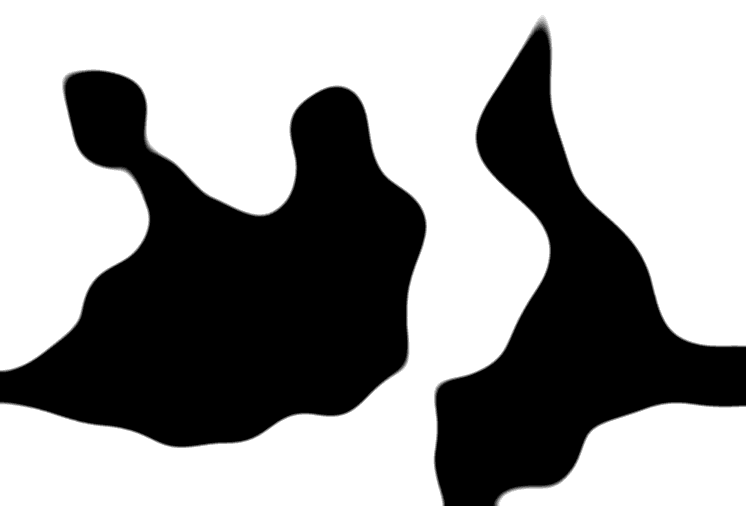

## Une définition mathématique

#### Terres émergées

[figure not shown]

#### Potentiel de surface

[figure not shown]

Source : **Didelon C., Richard Y. Grasland C., 2008,** Atlas de l’Europe dans le Monde, Paris, Documentation Française

## Une définition mathématique

#### Population totale

[figure not shown]

#### Potentiel de population

[figure not shown]

Source : **Didelon C., Richard Y. Grasland C., 2008,** Atlas de l’Europe dans le Monde, Paris, Documentation Française

## Une définition mathématique

#### PIB en volume

[figure not shown]

#### Potentiel de richesse

[figure not shown]

Source : **Didelon C., Richard Y. Grasland C., 2008,** Atlas de l’Europe dans le Monde, Paris, Documentation Française

## Des limites faussement évidentes …

“La plupart des manuels présentent l’Europe comme un « continent », c’est-à-dire un objet fini et évident, composé d’éléments divers (relief, climat, démographie, traditions populaires, activités économiques) dont le point commun primordial est d’être localisé à l’intérieur des frontières conventionnelles de ce continent. Cette approche tautologique, qui consiste à délimiter un ensemble géographique puis à caractériser son identité en fonction des éléments qu’il contient, laisse transparaître la persistance du vieux cadre épistémologique de la géographie régionale”. Source : [Brennetot & Rosenberg (2013)](https://journals-openedition-org.ezproxy.u-paris.fr/espacepolitique/2613?lang=en)

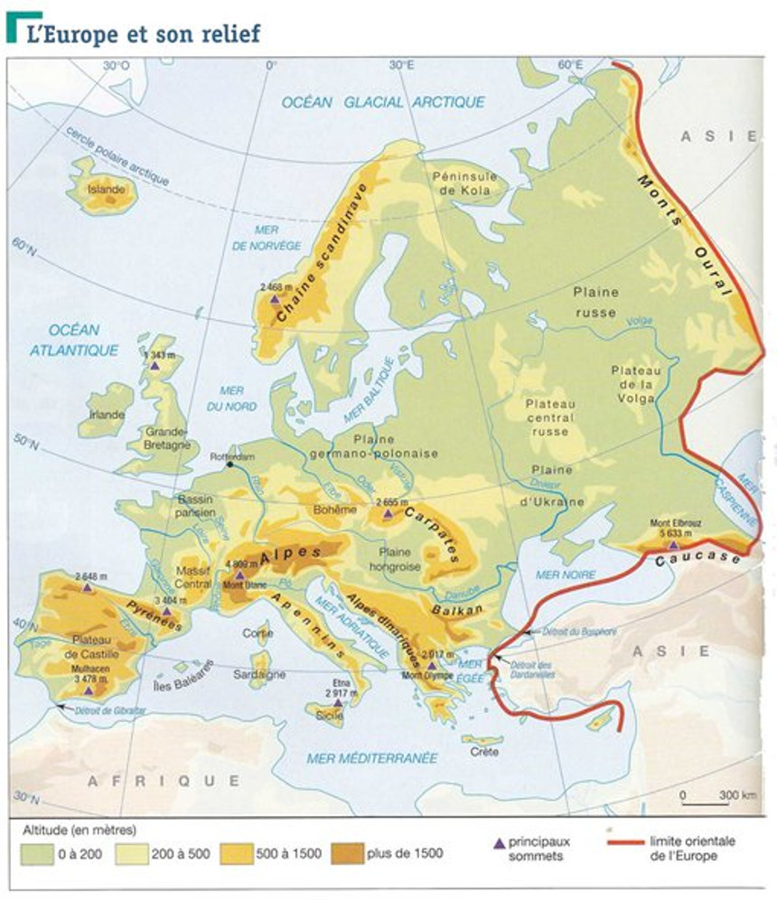